# Housing Bubble Shiny App

20/10/2019

## Objective

This presentation shows the use of my new Shiny app: *Housing Bubbles and Crises periods around the Globe*

[figure not shown]

This app shows the housing bubble periods for different countries and plots the price indicators with bubbles as shaded areas.

The app is completely functional. When bubbles are not identified nor table nor plot is depicted and an error appears. Change your country or indicator selection in this case.

## Usage of the App

In order to compute housing bubble periods you will have to choose the following two variables:

- **Country**: From the list you need to select the country code that you want to work with.
- **Indicator**: From the list you have two choose between Real house price index (rhpi) and Real house price to disposable income index (rhpi_rpdi).

Finally you have to click on the **Plot Bubbles** button and wait some seconds.

## Example

Suppose you select **Country:** *WRD* that refers to world and **Indicator:** *rhpi_rpdi* that refers to real house price to disposable income index. You will obtain:

```
##       [,1]         [,2]         [,3]         [,4]         [,5]
## start "1984-12-01" "1993-06-01" "2002-09-01" "2011-03-01" "2017-06-01"
## end   "1986-09-01" "2000-06-01" "2007-12-01" "2012-06-01" "2017-09-01"
```

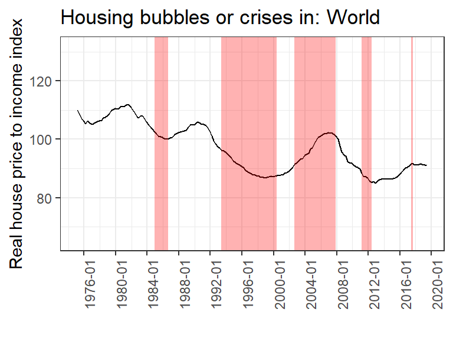

## Results

The resulting Bubble/Crisis Periods table shows the *start* and *end* of these events.

[figure not shown]

In the lower part you will see a plot of the selected indicator and the bubble period in a light-red shaded area. [My app](https://ssaninre22.shinyapps.io/HousePriceBubbleApp/)

**THANKS FOR YOUR ATTENTION AND ENJOY MY APP**